# hw2

Haley Humphries haley22

02/07/20

This homework is about syntax and basic plotting functions in R, and is **due by the end of Feb 7**.

You can use the RMarkDown file with these homework instructions as a template for your work. Make sure to replace “Your Name” and “your_github_username” in the YAML with your name and Github username.

**Submission instructions**: Create a folder named `ds202_hw2`, and name the RMarkDown file including your solutions `hw2.Rmd` under this folder. For submission, create a GitHub repository named `ds202_hw2` under your account, and push both `hw2.Rmd` and the knitted `hw2.html` to GitHub before the deadline. I will assume you use the same GitHub username as for your HW1 submission. The latest version of your homework appearing on GitHub before the deadline is graded. *It is crucial to follow the exact folder structure and file names*, so that your homework can be reproduced and graded by an automated script. Some questions will require the following answer format.

## Example question and answer

0. What is the smallest positive odd integer? Storage it in a variable named `a0` and print it.

**Example answer**: In the RMarkDown file, type in

````
```{r}
a0 <- 1
a0
```
````

The knitted html file will show:

```r
a0 <- 1
a0
```

```
## [1] 1
```

## R commands

1. Today’s temperature has a high of 24 and a low of 15 degree fahrenheit. Find the corresponding degress in celsius and storage it in a (single) vector named `cel`. Print the variable.

```r
temp = c(24, 15)
```

```r
cel = 5/9 * (temp-32)
cel
```

```
## [1] -4.444444 -9.444444
```

2. Create a vector of length 200. The odd entries should be 3 and even entries should be 1. Storage the created in a variable named `vec200` and print.

```r
vec200 <- 0
for (i in 1:200)
{
  if((i%%2)==0)
    vec200[i] <- 1
  else
    vec200[i] <- 3
  print(vec200[i])
}
```

```
## [1] 3
## [1] 1
## [1] 3
## [1] 1
## [1] 3
## [1] 1
## [1] 3
## [1] 1
## [1] 3
## [1] 1
## [1] 3
## [1] 1
## [1] 3
## [1] 1
## [1] 3
```

[output cut: 185 more lines]

3. How many perfect squares are there between 1 and 2001? Storage the answer in a variable named `numPerfect` and print. You may want to look at `?round`.

```r
numPerfect <- 0
for(i in 1:2001)
{
  J <- 1
  while((J*J)<=i)
  {
    if((J*J)==i)
      numPerfect=numPerfect+1
    J <- J+1
  }
  i<- i+1
}
print(numPerfect)
```

```
## [1] 44
```

## Cars and mileage

For this part we will use the `mpg` data set, you can access the data by first installing (using `install.packages('ggplot2')`) and then loading the package `ggplot2` (using `library(ggplot2)`) into your R session. The `mpg` data includes information about fuel economy of popular car models for the years 1999 and 2008 as collected by the US Environmental Protection Agency. An answer should include a short paragraph of text for the explanation to a (human) reader, together with appropriate R code, outputs, and graphs.

```r
library(ggplot2)
```

Most exercises are from the ggplot2 book section 2.2.1. You might find it helpful for working on the homework to read through this section. *However, all questions can be solved by using just the basic R graphics functions.*

1. What are the 3 most fuel-efficient models in terms of highway mileage? Storage the data frame (with 3 rows) containing all information of these three cars in a variable named `top3` and print.

```r
top3 <- head(mpg[order(mpg$hwy, decreasing=T),], n=3)
top3
```

```
## # A tibble: 3 x 11
##   manufacturer model  displ  year   cyl trans drv     cty   hwy fl    class
##   <chr>        <chr>  <dbl> <int> <int> <chr> <chr> <int> <int> <chr> <chr>
## 1 volkswagen   jetta    1.9  1999     4 manu… f        33    44 d     comp…
## 2 volkswagen   new b…   1.9  1999     4 manu… f        35    44 d     subc…
## 3 volkswagen   new b…   1.9  1999     4 auto… f        29    41 d     subc…
```

2. How many different compact models are included in this dataset? Storage the answer in a variable named `numCompact` and print.

```r
str(mpg)
```

```
## Classes 'tbl_df', 'tbl' and 'data.frame':    234 obs. of  11 variables:
##  $ manufacturer: chr  "audi" "audi" "audi" "audi" ...
##  $ model       : chr  "a4" "a4" "a4" "a4" ...
##  $ displ       : num  1.8 1.8 2 2 2.8 2.8 3.1 1.8 1.8 2 ...
##  $ year        : int  1999 1999 2008 2008 1999 1999 2008 1999 1999 2008 ...
##  $ cyl         : int  4 4 4 4 6 6 6 4 4 4 ...
##  $ trans       : chr  "auto(l5)" "manual(m5)" "manual(m6)" "auto(av)" ...
##  $ drv         : chr  "f" "f" "f" "f" ...
##  $ cty         : int  18 21 20 21 16 18 18 18 16 20 ...
##  $ hwy         : int  29 29 31 30 26 26 27 26 25 28 ...
##  $ fl          : chr  "p" "p" "p" "p" ...
##  $ class       : chr  "compact" "compact" "compact" "compact" ...
```

```r
numCompact <- subset(mpg, class == "compact")
```

```r
summary(numCompact)
```

```
##  manufacturer          model               displ            year
##  Length:47          Length:47          Min.   :1.800   Min.   :1999
##  Class :character   Class :character   1st Qu.:2.000   1st Qu.:1999
##  Mode  :character   Mode  :character   Median :2.200   Median :1999
##                                        Mean   :2.326   Mean   :2003
##                                        3rd Qu.:2.800   3rd Qu.:2008
##                                        Max.   :3.300   Max.   :2008
##       cyl           trans               drv                 cty
##  Min.   :4.000   Length:47          Length:47          Min.   :15.00
##  1st Qu.:4.000   Class :character   Class :character   1st Qu.:18.00
##  Median :4.000   Mode  :character   Mode  :character   Median :20.00
##  Mean   :4.596                                         Mean   :20.13
##  3rd Qu.:6.000                                         3rd Qu.:21.00
##  Max.   :6.000                                         Max.   :33.00
##       hwy            fl               class
##  Min.   :23.0   Length:47          Length:47
##  1st Qu.:26.0   Class :character   Class :character
##  Median :27.0   Mode  :character   Mode  :character
##  Mean   :28.3
##  3rd Qu.:29.0
##  Max.   :44.0
```

Length is 47.

3. Create a scatterplot of `hwy` and `cty` and describe the relationship. Why are there so few points visible? Explain your findings.

```r
x <- mpg$hwy
y <- mpg$cty
```

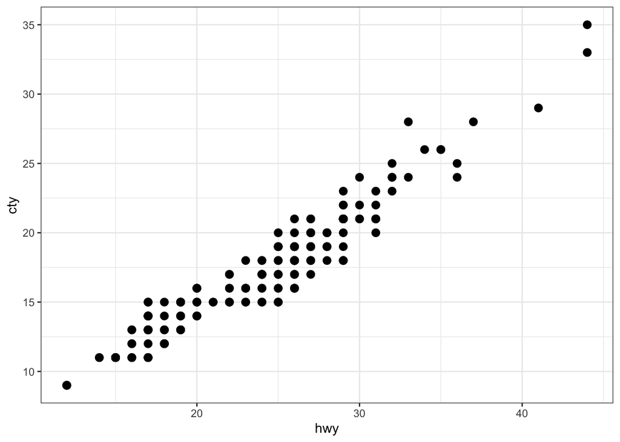

```r
ggplot(mpg, aes(x=hwy, y=cty)) + geom_point(shape=16, size=3) + theme_bw()
```

Highway mileage is better than city mileage.

4. Are cars in 2008 more fuel efficient than cars in 1999? Use graphs *and* summary statistics to answer this question. Explain your findings.

Note: your submission is supposed to be fully reproducible, i.e. the TA and I will ‘knit’ your submission. Make sure that you don’t use any file structure that depends on your computing environment.

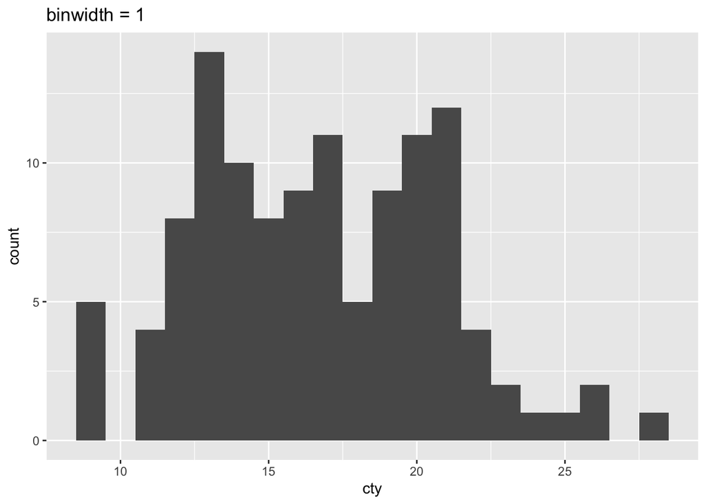

```r
cars2008 <- subset(mpg, year== 2008)
cars1999 <- subset(mpg, year== 1999)
ggplot(cars2008, aes(x = cty)) +
  geom_histogram(binwidth = 1) +
  ggtitle("binwidth = 1")
```

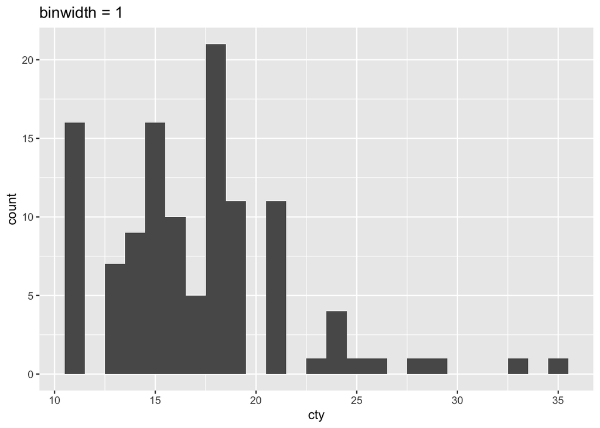

```r
  ggplot(cars1999, aes(x = cty)) +
  geom_histogram(binwidth = 1) +
  ggtitle("binwidth = 1")
```

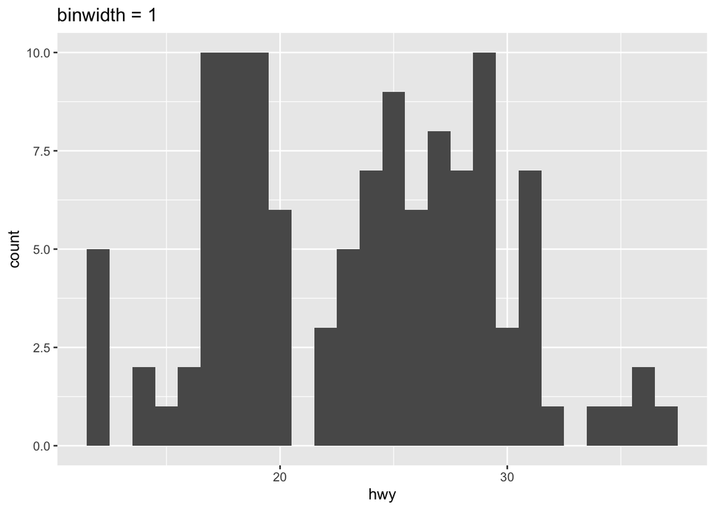

```r
  ggplot(cars2008, aes(x = hwy)) +
  geom_histogram(binwidth = 1) +
  ggtitle("binwidth = 1")
```

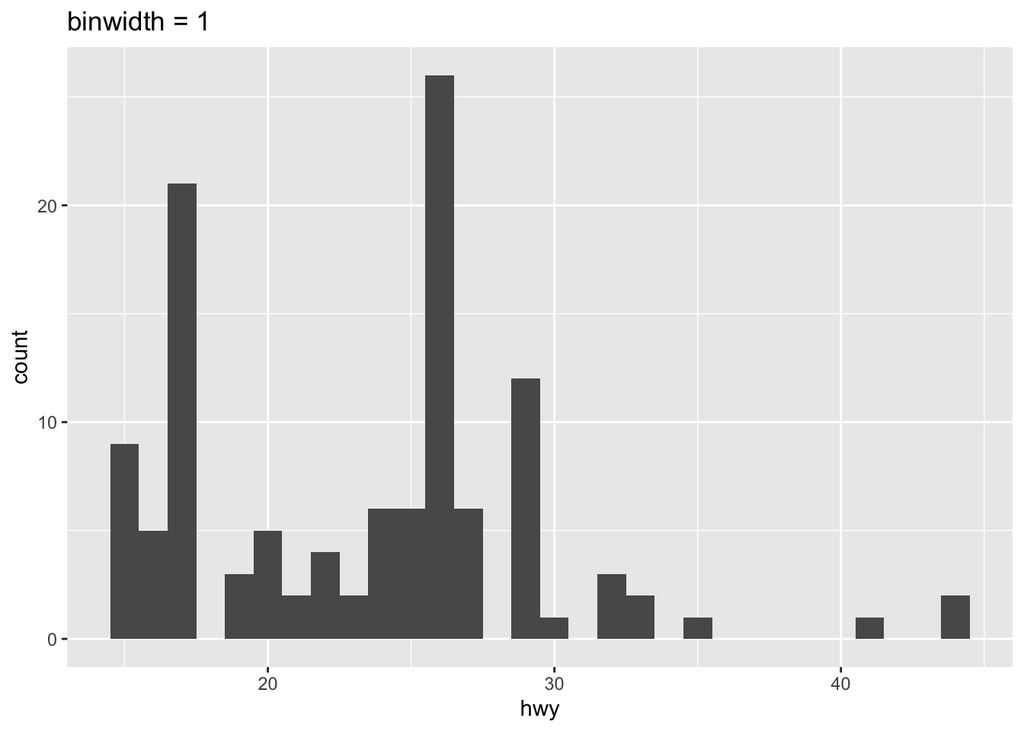

```r
  ggplot(cars1999, aes(x = hwy)) +
  geom_histogram(binwidth = 1) +
  ggtitle("binwidth = 1")
```

```r
mean(cars2008$cty)
```

```
## [1] 16.70085
```

```r
mean(cars2008$hwy)
```

```
## [1] 23.45299
```

```r
mean(cars1999$cty)
```

```
## [1] 17.01709
```

```r
mean(cars1999$hwy)
```

```
## [1] 23.42735
```

By creating these graphs and looking at the means you can see that nothing really improved over those 9 years and city mileage even decreased.